# Module 5

don-E Merson

October 23, 2017

# Module 5 Goals

- What is dplr?
- What is dplyr a good data solution?
- What are single table functions in dplyr?
- What are aggregate functions in dplyr?
- What are the different joins?
- What is dfsql?

# dplyr

- Package to manipulate data similar in consistent way
- Table is tibble
- After transformation is still tibble
- Other packages : Matrix ->operation >Vector
- Consistency allows tricks #These are the same

```r
library(dplyr)
tbl_df(mtcars) %>%
  filter(cyl=="8cyl") %>%
    arrange(hp) %>%
    select(hp,am,gear) %>%
    unique()
```

```
## # A tibble: 0 x 3
## # ... with 3 variables: hp <dbl>, am <dbl>, gear <dbl>
```

And

```r
mtcars2 <-tbl_df(mtcars)
mtcars2 <- filter(mtcars2, cyl=="8cyl" )
mtcars2 <- arrange(mtcars2,hp)
mtcars2 <- select (mtcars2,hp, am,gear)
mtcars2 <- unique(mtcars2)
mtcars2
```

```
## # A tibble: 0 x 3
## # ... with 3 variables: hp <dbl>, am <dbl>, gear <dbl>
```

Assumes results is first parameter to next function # flights https://cran.r-project.org/web/packages/dplyr/vignettes/dplyr.html

```r
#install.packages("nycflights13")
library(nycflights13)
```

```r
str(flights)
```

```
## Classes 'tbl_df', 'tbl' and 'data.frame':    336776 obs. of  19 variables:
##  $ year          : int  2013 2013 2013 2013 2013 2013 2013 2013 2013 2013 ...
##  $ month         : int  1 1 1 1 1 1 1 1 1 1 ...
##  $ day           : int  1 1 1 1 1 1 1 1 1 1 ...
##  $ dep_time      : int  517 533 542 544 554 554 555 557 557 558 ...
##  $ sched_dep_time: int  515 529 540 545 600 558 600 600 600 600 ...
##  $ dep_delay     : num  2 4 2 -1 -6 -4 -5 -3 -3 -2 ...
##  $ arr_time      : int  830 850 923 1004 812 740 913 709 838 753 ...
##  $ sched_arr_time: int  819 830 850 1022 837 728 854 723 846 745 ...
##  $ arr_delay     : num  11 20 33 -18 -25 12 19 -14 -8 8 ...
##  $ carrier       : chr  "UA" "UA" "AA" "B6" ...
##  $ flight        : int  1545 1714 1141 725 461 1696 507 5708 79 301 ...
##  $ tailnum       : chr  "N14228" "N24211" "N619AA" "N804JB" ...
##  $ origin        : chr  "EWR" "LGA" "JFK" "JFK" ...
##  $ dest          : chr  "IAH" "IAH" "MIA" "BQN" ...
##  $ air_time      : num  227 227 160 183 116 150 158 53 140 138 ...
##  $ distance      : num  1400 1416 1089 1576 762 ...
##  $ hour          : num  5 5 5 5 6 5 6 6 6 6 ...
##  $ minute        : num  15 29 40 45 0 58 0 0 0 0 ...
##  $ time_hour     : POSIXct, format: "2013-01-01 05:00:00" "2013-01-01 05:00:00" ...
```

# What items are incorrect type?

- What is a type?
- How about year, month, and day?
- What are pros and cons?
- How about carrier, origin, and dest?
- What are pros and cons? #Converting type for data

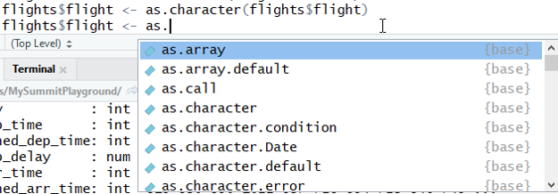

  #dplyr operations on one table

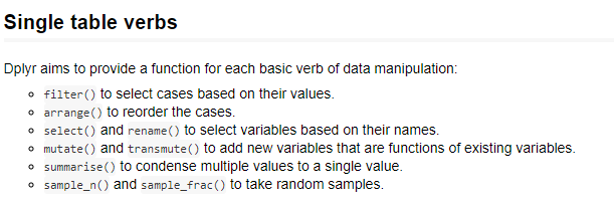

  #Group operations

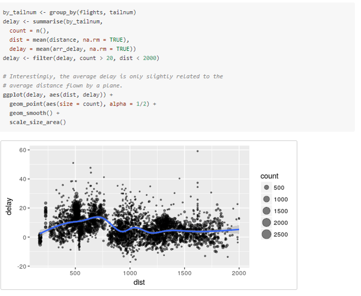

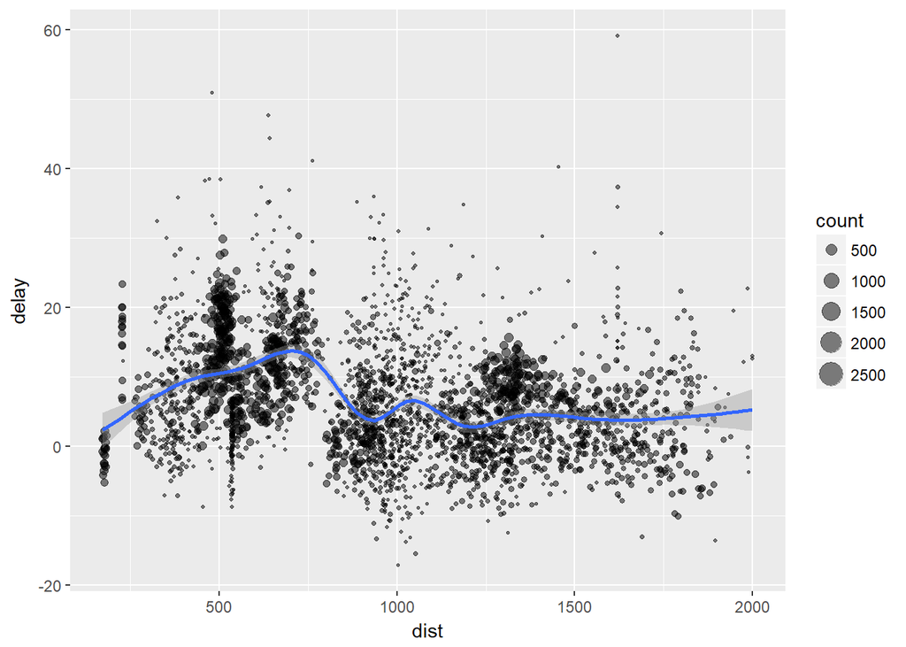

```r
library(ggplot2)
by_tailnum <- group_by(flights, tailnum)
delay <- summarise(by_tailnum,
  count = n(),
  dist = mean(distance, na.rm = TRUE),
  delay = mean(arr_delay, na.rm = TRUE))
delay <- filter(delay, count > 20, dist < 2000)

# Interestingly, the average delay is only slightly related to the
# average distance flown by a plane.
ggplot(delay, aes(dist, delay)) +
  geom_point(aes(size = count), alpha = 1/2) +
  geom_smooth() +
  scale_size_area()
```

# Combing columns

```r
state_data <- tbl_df(datasets::state.x77)
state_abb <- tbl_df(datasets::state.abb)
state_name <- tbl_df(datasets::state.name)
state_geo_center <-tbl_df(state.center)
final_state <- cbind(state_abb,state_name)
colnames(final_state) <- c("Abbreviation","LongName")
final_state <-cbind(final_state,state_geo_center)
final_state <- cbind(final_state, state_data)
glimpse(final_state)
```

```
## Observations: 50
## Variables: 12
## $ Abbreviation <chr> "AL", "AK", "AZ", "AR", "CA", "CO", "CT", "DE", "...
## $ LongName     <chr> "Alabama", "Alaska", "Arizona", "Arkansas", "Cali...
## $ x            <dbl> -86.7509, -127.2500, -111.6250, -92.2992, -119.77...
## $ y            <dbl> 32.5901, 49.2500, 34.2192, 34.7336, 36.5341, 38.6...
## $ Population   <dbl> 3615, 365, 2212, 2110, 21198, 2541, 3100, 579, 82...
## $ Income       <dbl> 3624, 6315, 4530, 3378, 5114, 4884, 5348, 4809, 4...
## $ Illiteracy   <dbl> 2.1, 1.5, 1.8, 1.9, 1.1, 0.7, 1.1, 0.9, 1.3, 2.0,...
## $ Life Exp     <dbl> 69.05, 69.31, 70.55, 70.66, 71.71, 72.06, 72.48, ...
## $ Murder       <dbl> 15.1, 11.3, 7.8, 10.1, 10.3, 6.8, 3.1, 6.2, 10.7,...
## $ HS Grad      <dbl> 41.3, 66.7, 58.1, 39.9, 62.6, 63.9, 56.0, 54.6, 5...
## $ Frost        <dbl> 20, 152, 15, 65, 20, 166, 139, 103, 11, 60, 0, 12...
## $ Area         <dbl> 50708, 566432, 113417, 51945, 156361, 103766, 486...
```

# Getting data to join

https://data.world/ian/united-states-university-rankings/workspace/file?filename=TICAS+Percentage+of+2015+Graduates+with+Debt+and+Average+Debt+of+those+with+Loans%2C+by+State.xlsx

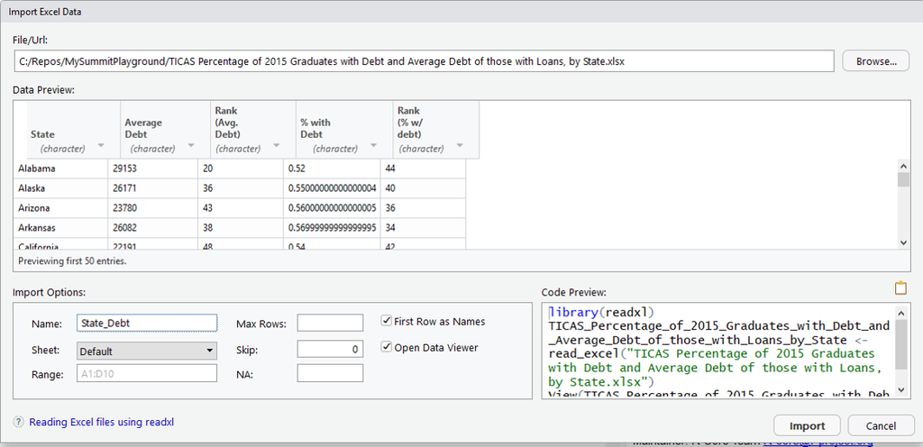

```r
library(readxl)
State_Debt <- read_excel("../../Data/Ticas.xlsx")
```

# Joining tables

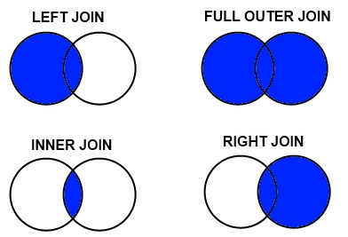

- Iinner_join - left_join -right_join - full_join

Think about it first

```r
glimpse(final_state)
```

```
## Observations: 50
## Variables: 12
## $ Abbreviation <chr> "AL", "AK", "AZ", "AR", "CA", "CO", "CT", "DE", "...
## $ LongName     <chr> "Alabama", "Alaska", "Arizona", "Arkansas", "Cali...
## $ x            <dbl> -86.7509, -127.2500, -111.6250, -92.2992, -119.77...
## $ y            <dbl> 32.5901, 49.2500, 34.2192, 34.7336, 36.5341, 38.6...
## $ Population   <dbl> 3615, 365, 2212, 2110, 21198, 2541, 3100, 579, 82...
## $ Income       <dbl> 3624, 6315, 4530, 3378, 5114, 4884, 5348, 4809, 4...
## $ Illiteracy   <dbl> 2.1, 1.5, 1.8, 1.9, 1.1, 0.7, 1.1, 0.9, 1.3, 2.0,...
## $ Life Exp     <dbl> 69.05, 69.31, 70.55, 70.66, 71.71, 72.06, 72.48, ...
## $ Murder       <dbl> 15.1, 11.3, 7.8, 10.1, 10.3, 6.8, 3.1, 6.2, 10.7,...
## $ HS Grad      <dbl> 41.3, 66.7, 58.1, 39.9, 62.6, 63.9, 56.0, 54.6, 5...
## $ Frost        <dbl> 20, 152, 15, 65, 20, 166, 139, 103, 11, 60, 0, 12...
## $ Area         <dbl> 50708, 566432, 113417, 51945, 156361, 103766, 486...
```

```r
glimpse(State_Debt)
```

```
## Observations: 51
## Variables: 5
## $ State            <chr> "Alabama", "Alaska", "Arizona", "Arkansas", "...
## $ Average Debt     <chr> "29153", "26171", "23780", "26082", "22191", ...
## $ Rank (Avg. Debt) <chr> "20", "36", "43", "38", "48", "39", "3", "4",...
## $ % with Debt      <chr> "0.52", "0.55000000000000004", "0.56000000000...
## $ Rank (% w/ debt) <chr> "44", "40", "36", "34", "42", "36", "14", "13...
```

How many records on inner join vs. full join?

# Inner join

```r
glimpse(inner_join(final_state,State_Debt, by=c("LongName"="State")))
```

```
## Observations: 50
## Variables: 16
## $ Abbreviation     <chr> "AL", "AK", "AZ", "AR", "CA", "CO", "CT", "DE...
## $ LongName         <chr> "Alabama", "Alaska", "Arizona", "Arkansas", "...
## $ x                <dbl> -86.7509, -127.2500, -111.6250, -92.2992, -11...
## $ y                <dbl> 32.5901, 49.2500, 34.2192, 34.7336, 36.5341, ...
## $ Population       <dbl> 3615, 365, 2212, 2110, 21198, 2541, 3100, 579...
## $ Income           <dbl> 3624, 6315, 4530, 3378, 5114, 4884, 5348, 480...
## $ Illiteracy       <dbl> 2.1, 1.5, 1.8, 1.9, 1.1, 0.7, 1.1, 0.9, 1.3, ...
## $ Life Exp         <dbl> 69.05, 69.31, 70.55, 70.66, 71.71, 72.06, 72....
## $ Murder           <dbl> 15.1, 11.3, 7.8, 10.1, 10.3, 6.8, 3.1, 6.2, 1...
## $ HS Grad          <dbl> 41.3, 66.7, 58.1, 39.9, 62.6, 63.9, 56.0, 54....
## $ Frost            <dbl> 20, 152, 15, 65, 20, 166, 139, 103, 11, 60, 0...
## $ Area             <dbl> 50708, 566432, 113417, 51945, 156361, 103766,...
## $ Average Debt     <chr> "29153", "26171", "23780", "26082", "22191", ...
## $ Rank (Avg. Debt) <chr> "20", "36", "43", "38", "48", "39", "3", "4",...
## $ % with Debt      <chr> "0.52", "0.55000000000000004", "0.56000000000...
## $ Rank (% w/ debt) <chr> "44", "40", "36", "34", "42", "36", "14", "13...
```

# Left join

```r
glimpse(left_join(final_state,State_Debt, by=c("LongName"="State")))
```

```
## Observations: 50
## Variables: 16
## $ Abbreviation     <chr> "AL", "AK", "AZ", "AR", "CA", "CO", "CT", "DE...
## $ LongName         <chr> "Alabama", "Alaska", "Arizona", "Arkansas", "...
## $ x                <dbl> -86.7509, -127.2500, -111.6250, -92.2992, -11...
## $ y                <dbl> 32.5901, 49.2500, 34.2192, 34.7336, 36.5341, ...
## $ Population       <dbl> 3615, 365, 2212, 2110, 21198, 2541, 3100, 579...
## $ Income           <dbl> 3624, 6315, 4530, 3378, 5114, 4884, 5348, 480...
## $ Illiteracy       <dbl> 2.1, 1.5, 1.8, 1.9, 1.1, 0.7, 1.1, 0.9, 1.3, ...
## $ Life Exp         <dbl> 69.05, 69.31, 70.55, 70.66, 71.71, 72.06, 72....
## $ Murder           <dbl> 15.1, 11.3, 7.8, 10.1, 10.3, 6.8, 3.1, 6.2, 1...
## $ HS Grad          <dbl> 41.3, 66.7, 58.1, 39.9, 62.6, 63.9, 56.0, 54....
## $ Frost            <dbl> 20, 152, 15, 65, 20, 166, 139, 103, 11, 60, 0...
## $ Area             <dbl> 50708, 566432, 113417, 51945, 156361, 103766,...
## $ Average Debt     <chr> "29153", "26171", "23780", "26082", "22191", ...
## $ Rank (Avg. Debt) <chr> "20", "36", "43", "38", "48", "39", "3", "4",...
## $ % with Debt      <chr> "0.52", "0.55000000000000004", "0.56000000000...
## $ Rank (% w/ debt) <chr> "44", "40", "36", "34", "42", "36", "14", "13...
```

# Right join

```r
glimpse(right_join(final_state,State_Debt, by=c("LongName"="State")))
```

```
## Observations: 51
## Variables: 16
## $ Abbreviation     <chr> "AL", "AK", "AZ", "AR", "CA", "CO", "CT", "DE...
## $ LongName         <chr> "Alabama", "Alaska", "Arizona", "Arkansas", "...
## $ x                <dbl> -86.7509, -127.2500, -111.6250, -92.2992, -11...
## $ y                <dbl> 32.5901, 49.2500, 34.2192, 34.7336, 36.5341, ...
## $ Population       <dbl> 3615, 365, 2212, 2110, 21198, 2541, 3100, 579...
## $ Income           <dbl> 3624, 6315, 4530, 3378, 5114, 4884, 5348, 480...
## $ Illiteracy       <dbl> 2.1, 1.5, 1.8, 1.9, 1.1, 0.7, 1.1, 0.9, NA, 1...
## $ Life Exp         <dbl> 69.05, 69.31, 70.55, 70.66, 71.71, 72.06, 72....
## $ Murder           <dbl> 15.1, 11.3, 7.8, 10.1, 10.3, 6.8, 3.1, 6.2, N...
## $ HS Grad          <dbl> 41.3, 66.7, 58.1, 39.9, 62.6, 63.9, 56.0, 54....
## $ Frost            <dbl> 20, 152, 15, 65, 20, 166, 139, 103, NA, 11, 6...
## $ Area             <dbl> 50708, 566432, 113417, 51945, 156361, 103766,...
## $ Average Debt     <chr> "29153", "26171", "23780", "26082", "22191", ...
## $ Rank (Avg. Debt) <chr> "20", "36", "43", "38", "48", "39", "3", "4",...
## $ % with Debt      <chr> "0.52", "0.55000000000000004", "0.56000000000...
## $ Rank (% w/ debt) <chr> "44", "40", "36", "34", "42", "36", "14", "13...
```

# Full Join

```r
glimpse(full_join(final_state,State_Debt, by=c("LongName"="State")))
```

```
## Observations: 51
## Variables: 16
## $ Abbreviation     <chr> "AL", "AK", "AZ", "AR", "CA", "CO", "CT", "DE...
## $ LongName         <chr> "Alabama", "Alaska", "Arizona", "Arkansas", "...
## $ x                <dbl> -86.7509, -127.2500, -111.6250, -92.2992, -11...
## $ y                <dbl> 32.5901, 49.2500, 34.2192, 34.7336, 36.5341, ...
## $ Population       <dbl> 3615, 365, 2212, 2110, 21198, 2541, 3100, 579...
## $ Income           <dbl> 3624, 6315, 4530, 3378, 5114, 4884, 5348, 480...
## $ Illiteracy       <dbl> 2.1, 1.5, 1.8, 1.9, 1.1, 0.7, 1.1, 0.9, 1.3, ...
## $ Life Exp         <dbl> 69.05, 69.31, 70.55, 70.66, 71.71, 72.06, 72....
## $ Murder           <dbl> 15.1, 11.3, 7.8, 10.1, 10.3, 6.8, 3.1, 6.2, 1...
## $ HS Grad          <dbl> 41.3, 66.7, 58.1, 39.9, 62.6, 63.9, 56.0, 54....
## $ Frost            <dbl> 20, 152, 15, 65, 20, 166, 139, 103, 11, 60, 0...
## $ Area             <dbl> 50708, 566432, 113417, 51945, 156361, 103766,...
## $ Average Debt     <chr> "29153", "26171", "23780", "26082", "22191", ...
## $ Rank (Avg. Debt) <chr> "20", "36", "43", "38", "48", "39", "3", "4",...
## $ % with Debt      <chr> "0.52", "0.55000000000000004", "0.56000000000...
## $ Rank (% w/ debt) <chr> "44", "40", "36", "34", "42", "36", "14", "13...
```

# Seamless inner join

If name is the same will auto connect

```r
final_state <- rename(final_state, "State"=LongName)
head(final_state)
```

```
##   Abbreviation      State         x       y Population Income Illiteracy
## 1           AL    Alabama  -86.7509 32.5901       3615   3624        2.1
## 2           AK     Alaska -127.2500 49.2500        365   6315        1.5
## 3           AZ    Arizona -111.6250 34.2192       2212   4530        1.8
## 4           AR   Arkansas  -92.2992 34.7336       2110   3378        1.9
## 5           CA California -119.7730 36.5341      21198   5114        1.1
## 6           CO   Colorado -105.5130 38.6777       2541   4884        0.7
##   Life Exp Murder HS Grad Frost   Area
## 1    69.05   15.1    41.3    20  50708
## 2    69.31   11.3    66.7   152 566432
## 3    70.55    7.8    58.1    15 113417
## 4    70.66   10.1    39.9    65  51945
## 5    71.71   10.3    62.6    20 156361
## 6    72.06    6.8    63.9   166 103766
```

```r
glimpse(full_join(final_state,State_Debt))
```

```
## Observations: 51
## Variables: 16
## $ Abbreviation     <chr> "AL", "AK", "AZ", "AR", "CA", "CO", "CT", "DE...
## $ State            <chr> "Alabama", "Alaska", "Arizona", "Arkansas", "...
## $ x                <dbl> -86.7509, -127.2500, -111.6250, -92.2992, -11...
## $ y                <dbl> 32.5901, 49.2500, 34.2192, 34.7336, 36.5341, ...
## $ Population       <dbl> 3615, 365, 2212, 2110, 21198, 2541, 3100, 579...
## $ Income           <dbl> 3624, 6315, 4530, 3378, 5114, 4884, 5348, 480...
## $ Illiteracy       <dbl> 2.1, 1.5, 1.8, 1.9, 1.1, 0.7, 1.1, 0.9, 1.3, ...
## $ Life Exp         <dbl> 69.05, 69.31, 70.55, 70.66, 71.71, 72.06, 72....
## $ Murder           <dbl> 15.1, 11.3, 7.8, 10.1, 10.3, 6.8, 3.1, 6.2, 1...
## $ HS Grad          <dbl> 41.3, 66.7, 58.1, 39.9, 62.6, 63.9, 56.0, 54....
## $ Frost            <dbl> 20, 152, 15, 65, 20, 166, 139, 103, 11, 60, 0...
## $ Area             <dbl> 50708, 566432, 113417, 51945, 156361, 103766,...
## $ Average Debt     <chr> "29153", "26171", "23780", "26082", "22191", ...
## $ Rank (Avg. Debt) <chr> "20", "36", "43", "38", "48", "39", "3", "4",...
## $ % with Debt      <chr> "0.52", "0.55000000000000004", "0.56000000000...
## $ Rank (% w/ debt) <chr> "44", "40", "36", "34", "42", "36", "14", "13...
```

```r
glimpse(full_join(final_state,State_Debt,by="State"))
```

```
## Observations: 51
## Variables: 16
## $ Abbreviation     <chr> "AL", "AK", "AZ", "AR", "CA", "CO", "CT", "DE...
## $ State            <chr> "Alabama", "Alaska", "Arizona", "Arkansas", "...
## $ x                <dbl> -86.7509, -127.2500, -111.6250, -92.2992, -11...
## $ y                <dbl> 32.5901, 49.2500, 34.2192, 34.7336, 36.5341, ...
## $ Population       <dbl> 3615, 365, 2212, 2110, 21198, 2541, 3100, 579...
## $ Income           <dbl> 3624, 6315, 4530, 3378, 5114, 4884, 5348, 480...
## $ Illiteracy       <dbl> 2.1, 1.5, 1.8, 1.9, 1.1, 0.7, 1.1, 0.9, 1.3, ...
## $ Life Exp         <dbl> 69.05, 69.31, 70.55, 70.66, 71.71, 72.06, 72....
## $ Murder           <dbl> 15.1, 11.3, 7.8, 10.1, 10.3, 6.8, 3.1, 6.2, 1...
## $ HS Grad          <dbl> 41.3, 66.7, 58.1, 39.9, 62.6, 63.9, 56.0, 54....
## $ Frost            <dbl> 20, 152, 15, 65, 20, 166, 139, 103, 11, 60, 0...
## $ Area             <dbl> 50708, 566432, 113417, 51945, 156361, 103766,...
## $ Average Debt     <chr> "29153", "26171", "23780", "26082", "22191", ...
## $ Rank (Avg. Debt) <chr> "20", "36", "43", "38", "48", "39", "3", "4",...
## $ % with Debt      <chr> "0.52", "0.55000000000000004", "0.56000000000...
## $ Rank (% w/ debt) <chr> "44", "40", "36", "34", "42", "36", "14", "13...
```

# sqldf

- Can translate to sql
- Allows for multiple table join

```r
#install.packages("sqldf")
library(sqldf)
sqldf("select Abbreviation,Population from final_state
      inner join State_Debt
      on final_state.State=State_Debt.State

      ")
```

```
##    Abbreviation Population
## 1            AL       3615
## 2            AK        365
## 3            AZ       2212
## 4            AR       2110
## 5            CA      21198
## 6            CO       2541
## 7            CT       3100
## 8            DE        579
## 9            FL       8277
## 10           GA       4931
## 11           HI        868
## 12           ID        813
## 13           IL      11197
## 14           IN       5313
```

[output cut: 36 more lines]

# SQL Keywords

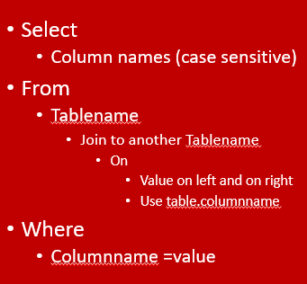

Select Column names (case sensitive) From Tablename Join to another Tablenamem On Value on left and on right Use table.columnname Where Columnname =value